# Stroke Prediction

Guillermo Martinez Dibene

11th of May, 2021

# The Stroke Prediction Challenge

In this presentation I am going to study a data set from the data analysis challenges website: Kaggle.

This data set can be found here [Stroke](https://www.kaggle.com/fedesoriano/stroke-prediction-dataset)

The idea is to predict if a given patient will have a stroke given a series of features of the patient.

# Description of the features

| Feature | Description |
| --- | --- |
| `gender` | A categorical variable with three levels: “Male”, “Female” and “Other” |
| `age` | A continuous variable indicating the age of the patient |
| `hypertention` | A dummy variable indicating if the patient has hypertension |
| `heart_disease` | A dummy variable indicating if the patient has heart disease |
| `ever_married` | A dummy variable indicating if the patient has ever been married |
| `work_type` | A categorical variable with 5 levels: “children”, “Govt_job”, “Never_worked”, “Private” and “Self-employed” |
| `residence_type` | A categorical variable with two levels: “Urban” and “Rural” |
| `avg_glucose_level` | A continuous variable indicating the average glucose level in the blood |
| `bmi` | A continuous variable indicating the body mass index of the patient |
| `smoking_status` | A categorical variable with 4 levels: “formerly smoked”, “never smoked”, “smokes” and “Unknown” (which means unavailable) |

| Respose | Description |
| --- | --- |
| `stroke` | A dummy variable with indicating if the patient had a stroke or not |

### Literature review.

The first thing to do, is to read what is already known about strokes. For example, I found the following information in the PHSA website (in this [link](http://www.phsa.ca/health-info/stroke)). The main risk factors for a stroke (both modifiable and non-modifiable) that appear in the features are: smoking, unhealthy weight (the feature `bmi` has weight in it), sex, medical history (both `hypertension` and `heart_disease` fall here).

# The set up

Now, I will load some libraries. I will mainly use base `R` together with the following libraries:

| Library | What for? |
| --- | --- |
| `tidyverse` | Data cleaning, munging and preprocessing; this is a whole ecosystem of libraries |
| `lvplot` | To plot violin plots with `ggplot2` |
| `MASS` | Linear and Quadratic Discriminant Analyses |
| `caret` | KNN |
| `bestglm` | Feature selection of `glm` models |
| `randomForest` | Random Forests |
| `gbm` | Boosting models |
| `e1071` | Many models but I use naïve Bayes from this library |
| `ROCR` | ROC curves |

Before loading the data, I quickly opened it in my spreadsheet viewer and it looks quite fine. I should have no problem loading it.

```r
data <- read_csv(
    r"(stroke_data.csv)",
    na = c("", "NA", "N/A")
)
```

### Some quick info of the data:

There are

```r
nrow(data)
```

```
## [1] 5110
```

observations

From the categorical data `gender`, we have

```r
data %>% count(gender)
```

```
## # A tibble: 3 x 2
##   gender     n
##   <chr>  <int>
## 1 Female  2994
## 2 Male    2115
## 3 Other      1
```

Unfortunately, there is only one observation for “Other” in `gender` which means we either have to process it or delete it from the data set.

```r
data %>% count(smoking_status)
```

```
## # A tibble: 4 x 2
##   smoking_status      n
##   <chr>           <int>
## 1 formerly smoked   885
## 2 never smoked     1892
## 3 smokes            789
## 4 Unknown          1544
```

This is quite bad since 30% of the observation is missing this important feature. We may need to consider every model with and without this variable.

```r
data %>% count(age)
```

```
## # A tibble: 104 x 2
##      age     n
##    <dbl> <int>
##  1  0.08     2
##  2  0.16     3
##  3  0.24     5
##  4  0.32     5
##  5  0.4      2
##  6  0.48     3
##  7  0.56     5
##  8  0.64     4
##  9  0.72     5
## 10  0.8      4
## # ... with 94 more rows
```

It seems that before age 2, babies are counted in a fraction of a year, probably the use months (1/12 = 0.833…) and round them to 0.08, this causes the jump from 1.88 to 2.0. We are going to alter this into 0 and 1. 0 will be the babies who are not 1 year old and 1 will be those between 1 and 2 years old.

We now check this data set for missing values.

```r
map(data, ~ sum(is.na(.)))
```

```
## $id
## [1] 0
##
## $gender
## [1] 0
##
## $age
## [1] 0
##
## $hypertension
## [1] 0
##
## $heart_disease
## [1] 0
##
## $ever_married
## [1] 0
##
## $work_type
## [1] 0
##
## $Residence_type
## [1] 0
##
## $avg_glucose_level
## [1] 0
##
## $bmi
## [1] 201
##
## $smoking_status
## [1] 0
##
## $stroke
## [1] 0
```

We see that only `bmi` has missing values. The variable `id` is not useful for us, so we will drop it.

Let us finally see if the response variable is evenly distributed

```r
data %>% count(stroke)
```

```
## # A tibble: 2 x 2
##   stroke     n
##    <dbl> <int>
## 1      0  4861
## 2      1   249
```

This is a data set where the response variable is rare, so we are probably more interested in the precision and sensitivity of the model as opposed to its accuracy.

# Some preprocessing

With this information, we can see that there are a few things we need to do.

1. I will drop the observation where `gender == "Other"`. Unfortunately, a single observation is not useful for data analysis.
2. The `bmi` is missing a few data points. Later, I will randomly split the data into training and test set; I will fill the missing `bmi` values with the *mean of the training set*.
3. Age needs some preprocessing too: those age less than two are given in fraction of a year and this is different from the rest of the data, we are going to make the spacing even by considering any observation between 0 and 1 to be 0 and between 1 and 2 to be 1.
4. The features `gender`, `ever_married`, `work_type`, `Residence_type` and `smoking_status` are considered characters. We have to transform them into unordered factors (this is the default of the `as_factor()` function).
5. I will do some feature engineering and consider “children” as “Never_worked”.

```r
data <- data %>%
    dplyr::select(gender:stroke) %>%
    filter(gender != "Other") %>%
    mutate(
        work_type = if_else(work_type == "children", "Never_worked", work_type), #If you take care of your children, we will consider you self-employed
        age = if_else(0 < age & age < 1, 0, age),
        age = if_else(1 <= age & age < 2, 1, age),
        ever_married = if_else(ever_married == "Yes", 1, 0),
        Residence_type = if_else(Residence_type == "Urban", 1, 0),

    ) %>%
    mutate(
        gender = as_factor(gender),
        work_type = as_factor(work_type),
        smoking_status = as_factor(smoking_status),
        stroke = as_factor(stroke)
    )
```

And a last peak at the data.

```r
tail(data)
```

```
## # A tibble: 6 x 11
##   gender   age hypertension heart_disease ever_married work_type  Residence_type
##   <fct>  <dbl>        <dbl>         <dbl>        <dbl> <fct>               <dbl>
## 1 Female    13            0             0            0 Never_wor~              0
## 2 Female    80            1             0            1 Private                 1
## 3 Female    81            0             0            1 Self-empl~              1
## 4 Female    35            0             0            1 Self-empl~              0
## 5 Male      51            0             0            1 Private                 0
## 6 Female    44            0             0            1 Govt_job                1
## # ... with 4 more variables: avg_glucose_level <dbl>, bmi <dbl>,
## #   smoking_status <fct>, stroke <fct>
```

Now everything looks to be of the right type of data.

### Train and test split

```r
set.seed(12)
train <- sample(1:nrow(data), size = 4100) #4100/5109 is roughly 80% of the data
data_train <- data[train, ]
data_test  <- data[-train, ]
```

### Imputing missing values

Although this is not the best strategy, we will impute all the missing values in `bmi` with the mean of the training data. There is roughly only 3% of missing values.

```r
bmi_mean = round(mean(data_train$bmi, na.rm = TRUE), digits = 1)

data_train <- data_train %>% replace_na(list(bmi = bmi_mean))
data_test  <- data_test %>% replace_na(list(bmi = bmi_mean))
```

# Some visualisations

I will use the library `ggplot2`. I will also code a `multiplot` function o display multiple plots together.

```r
multiplot <- function(..., plotlist=NULL, file, cols=1, layout=NULL, title = "") {
    library(grid)

    # Make a list from the ... arguments and plotlist
    plots <- c(list(...), plotlist)

    numPlots = length(plots)

    # If layout is NULL, then use 'cols' to determine layout
    if (is.null(layout)) {
        # Make the panel
        # ncol: Number of columns of plots
        # nrow: Number of rows needed, calculated from # of cols
        layout <- matrix(seq(1, cols * ceiling(numPlots/cols)),
                         ncol = cols, nrow = ceiling(numPlots/cols))
    }

    if (numPlots==1) {
        print(plots[[1]])

    } else if (title == "") {
        # Set up the page
        grid.newpage()
        pushViewport(viewport(layout = grid.layout(nrow(layout), ncol(layout))))

        # Make each plot, in the correct location
        for (i in 1:numPlots) {
            # Get the i,j matrix positions of the regions that contain this subplot
            matchidx <- as.data.frame(which(layout == i, arr.ind = TRUE))

            print(plots[[i]], vp = viewport(layout.pos.row = matchidx$row,
                                            layout.pos.col = matchidx$col))
        }
    } else {
        # Set up the page
        grid.newpage()
        #We add one row for the title
        pushViewport(
            viewport(
                layout = grid.layout(
                    nrow(layout) + 1,
                    ncol(layout),
                    heights = c(1, rep_len(10, ncol(layout)))
                )
            )
        )
        grid.text(label = title, vp = viewport(layout.pos.row = 1, layout.pos.col = 1:ncol(layout)))

        # Make each plot, in the correct location
        for (i in 1:numPlots) {
            # Get the i,j matrix positions of the regions that contain this subplot
            matchidx <- as.data.frame(which(layout == i, arr.ind = TRUE))

            print(plots[[i]], vp = viewport(layout.pos.row = matchidx$row + 1,
                                            layout.pos.col = matchidx$col))
        }
    }
}
```

# Age, Gender, Heart disease, Hypertension and Strokes

```r
plot_gender <- data_train %>% ggplot(aes(gender, fill = stroke)) +
    geom_bar(position = "fill") +
    labs(
        x = "Gender",
        y = "Proportion",
        fill = "Stroke?"
    ) +
    theme(
        legend.position = "none"
    ) +
    scale_fill_manual(
        values = c("lightblue", "darkred")
    )


plot_age_gender <- data_train %>% ggplot(aes(age, fill = stroke)) +
    geom_histogram(bins = 15) +
    facet_wrap(~ gender) +
    labs(
        x = "Age",
        y = "Number of individuals"
    ) +
    theme(
        legend.position = "none"
    ) +
    scale_fill_manual(
        values = c("lightblue", "darkred")
    )

plot_hyper <- data_train %>% mutate(hypertension = as_factor(if_else(hypertension == 1, "Yes", "No"))) %>%
    ggplot(aes(hypertension, fill = stroke)) +
    geom_bar(position = "fill") +
    labs(
        x = "Hypertension",
        y = "Proportion"
    ) +
    theme(
        legend.position = "none"
    ) +
    scale_fill_manual(
        values = c("lightblue", "darkred")
    )

plot_heart <- data_train %>% mutate(heart_disease = as_factor(if_else(heart_disease == 1, "Yes", "No"))) %>%
    ggplot(aes(heart_disease, fill = stroke)) +
    geom_bar(position = "fill") +
    labs(
        x = "Heart disease",
        y = "Proportion"
    ) +
    theme(
        legend.position = "none"
    ) +
    scale_fill_manual(
        values = c("lightblue", "darkred")
    )
```

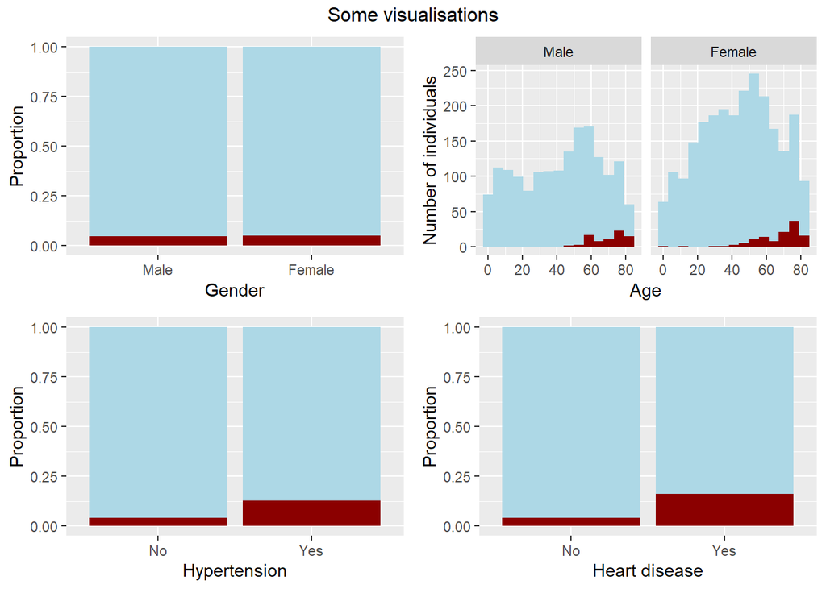

```r
multiplot(plot_gender, plot_hyper, plot_age_gender, plot_heart,
    cols = 2,
    title = "Some visualisations"
)
```

**Note:** somewhat surprisingly, `gender` does not affect stroke for this data set. That is,
$$\mathbf{P}(\mathrm{Stroke} = \mathrm{Yes} | \mathrm{Gender} = \mathrm{Male}) = \mathbf{P}(\mathrm{Stroke} = \mathrm{Yes} | \mathrm{Gender} = \mathrm{Female})$$
and same for $\mathrm{Stroke} = \mathrm{No}$.

# BMI, Glucose and Strokes

```r
plot_bmi_boxplot <- data_train %>% mutate(stroke = as_factor(if_else(stroke == 1, "Yes", "No"))) %>%
    ggplot(aes(stroke, bmi)) +
    geom_boxplot(outlier.alpha = 0.15) +
    labs(
        x = "Stroke",
        y = "Body Mass Index"
    )

plot_bmi_histogram <- data_train %>% mutate(stroke = as_factor(if_else(stroke == 1, "Yes", "No"))) %>%
    ggplot(aes(bmi, fill = stroke)) +
    geom_histogram(bins = 40) +
    labs(
        x = "Body Mass Index",
        y = "Count"
    ) +
    theme(
        legend.position = "none"
    ) +
    scale_fill_manual(
        values = c("lightblue", "darkred")
    )

plot_glucose_violin <- data_train %>% mutate(stroke = as_factor(if_else(stroke == 1, "Yes", "No"))) %>%
    ggplot(aes(stroke, avg_glucose_level)) +
    geom_violin() +
    geom_boxplot(width = 0.05, outlier.alpha = 0.05) +
    labs(
        x = "Stroke",
        y = "Avg. glucose level"
    )

plot_glucose_histogram <- data_train %>% mutate(stroke = as_factor(if_else(stroke == 1, "Yes", "No"))) %>%
    ggplot(aes(avg_glucose_level, fill = stroke)) +
    geom_histogram(bins = 40) +
    labs(
        x = "Avg. glucose level",
        y = "Count"
    ) +
    theme(
        legend.position = "none"
    ) +
    scale_fill_manual(
        values = c("lightblue", "darkred")
    )
```

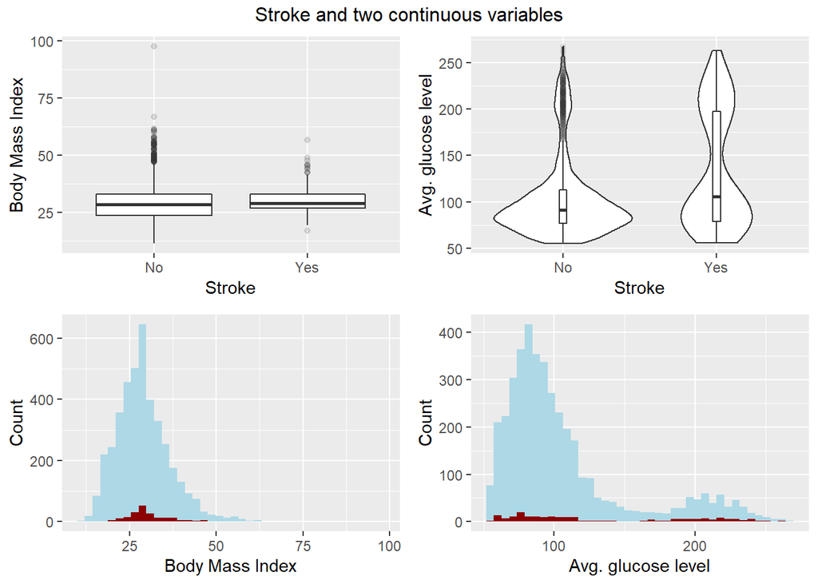

```r
multiplot(
    plot_bmi_boxplot, plot_bmi_histogram, plot_glucose_violin, plot_glucose_histogram,
    cols = 2,
    title = "Stroke and two continuous variables"
)
```

We see that `bmi` does not seem to influence strokes, again, somewhat surprisingly.

# Other categorical variables

```r
plot_smoking <- data_train %>% ggplot(aes(smoking_status, fill = stroke)) +
    geom_bar(position = "fill") +
    labs(
        x = "Smoking status",
        y = "Proportion"
    ) +
    theme(
        legend.position = "none"
    ) +
    scale_x_discrete(
        labels = c("Before", "Never", "Currently", "Unknown")
    ) +
    scale_fill_manual(
        values = c("lightblue", "darkred")
    )

plot_work <- data_train %>% ggplot(aes(work_type, fill = stroke)) +
    geom_bar(position = "fill") +
    labs(
        x = "Working type",
        y = "Proportion"
    ) +
    theme(
        legend.position = "none"
    ) +
    scale_x_discrete(
        labels = c("Priv.", "Self Emp.", "Gov.", "Never")
    ) +
    scale_fill_manual(
        values = c("lightblue", "darkred")
    )

plot_residence <- data_train %>% mutate(Residence = as_factor(if_else(Residence_type == 1, "Urban", "Rural"))) %>%
    ggplot(aes(Residence, fill = stroke)) +
    geom_bar(position = "fill") +
    labs(
        x = "Residence type",
        y = "Proportion"
    ) +
    theme(
        legend.position = "none"
    ) +
    scale_fill_manual(
        values = c("lightblue", "darkred")
    )

plot_married <- data_train %>% mutate(ever_married = as_factor(if_else(ever_married == 1, "Yes", "No"))) %>%
    ggplot(aes(ever_married, fill = stroke)) +
    geom_bar(position = "fill") +
    labs(
        x = "Have you ever been married?",
        y = "Proportion"
    ) +
    theme(
        legend.position = "none"
    ) +
    scale_fill_manual(
        values = c("lightblue", "darkred")
    )
```

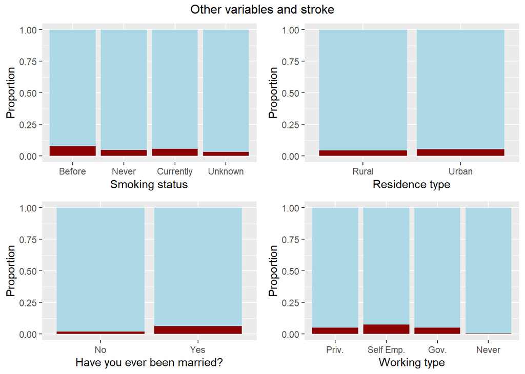

```r
multiplot(
    plot_smoking, plot_married, plot_residence, plot_work,
    cols = 2,
    title = "Other variables and stroke"
)
```

Interestingly, it would seem that “Never worked” prevents strokes. “People should stop working altogether!” On a serious note, we can check the ages of those who have never worked

```r
data_train %>% count(age, work_type) %>% filter(work_type == "Never_worked")
```

```
## # A tibble: 20 x 3
##      age work_type        n
##    <dbl> <fct>        <int>
##  1     0 Never_worked    33
##  2     1 Never_worked    66
##  3     2 Never_worked    39
##  4     3 Never_worked    37
##  5     4 Never_worked    32
##  6     5 Never_worked    54
##  7     6 Never_worked    20
##  8     7 Never_worked    27
##  9     8 Never_worked    46
## 10     9 Never_worked    28
## 11    10 Never_worked    31
## 12    11 Never_worked    29
## 13    12 Never_worked    33
## 14    13 Never_worked    39
## 15    14 Never_worked    21
## 16    15 Never_worked    18
## 17    16 Never_worked    11
## 18    17 Never_worked     3
## 19    18 Never_worked     2
## 20    19 Never_worked     1
```

All of them, babies, kids and teenagers. This is bad since one variable is a full predictor of another (age and work-type).

# Conclusions from the plots

The previous plots suggest the following preliminary conclusions.

| Variable | Related to strokes? |
| --- | --- |
| Gender | No |
| Age | Yes, seems strong |
| Hypertension | Yes, seems strong |
| Heart Disease | Yes, seems strong |
| Body Mass Index | No |
| Avg. Glucose level | Yes, seems weak |
| Smoking | Inconsistent plot |
| Residence type | No |
| Work type | No |
| Ever Married | Yes, seems strong |

**We will continue to work only with those features that seem related to stroke and smoking.**

```r
data_train <- data_train %>%
    dplyr::select(age, hypertension, heart_disease, avg_glucose_level, smoking_status, ever_married, stroke)
data_test <- data_test %>%
    dplyr::select(age, hypertension, heart_disease, avg_glucose_level, smoking_status, ever_married, stroke)
```

# First models

The most basic models to consider, that requires no parameter adjusting, are:

- Naïve Bayes Classifier
- Linear Discriminant Analysis
- Quadratic Discriminant Analysis
- Logistic Regression

We are going to fit all these classifiers using the selected variables above. Furthermore, we use the function `bestglm` from the package of the same name to perform an exhaustive search for the best feature selection in logistic regression. One caveat, `bestglm` is a bit tricky to use. Instead of accepting a formula, it requires a `data.frame` of the form Xy, where X is a design matrix and y is the response vector, but X should not have an intercept added for `bestglm` adds it itself. However, since we have categorical variables, creating a model matrix from `R` base functions will always create a column representing the intercept or will always use one of the categorical variables and add all the levels.

### Naïve Bayes Classifier

We finally create a Naïve Bayes Classifier, which also requires no parameter adjusting.

```r
model_naive <- naiveBayes(
    stroke ~ .,
    data = data_train
)
```

### Linear discriminant analysis

This model assumes that the distribution of the features, given the response, follows a Guassian distribution, whose matrix of covariances is not a function of the response. This results in a linear boundary between the responses.

```r
model_lda <- lda(
    stroke ~ .,
    data = data_train
)
```

### Quadratic discriminant analysis

Similar to linear discriminant analysis except that now the different classes are allowed to have their own matrix of covariances. This results in a quadratic boundary.

```r
model_qda <- qda(
    stroke ~ .,
    data = data_train
)
```

# Logistic regression

As mentioned earlier, we now do a full exhaustive search. Since there are 2 continuous features, 3 binary and 1 categorical with 4 levels, the following code will actually test all $2^8 = 256$ models for us.

```r
X_train <- model.matrix(
    stroke ~ 0 + age + hypertension + heart_disease + avg_glucose_level + ever_married + smoking_status,
    data = data_train
)
X_train <- X_train[, 1:(ncol(X_train)-1)] #We discard the column corresponding to Unknown smoking and this is absorbed by the intercept which is automatically added by bestglm

#Use as.data.frame here since tibbles coerce each column as a list while a data frame will keep the vectors
Xy_train <- as.data.frame(cbind(X_train, data_train[, "stroke"]))
model_logis_BIC <- bestglm(
    Xy_train, #Data has to be of the form [design_matrix, reponse_vector]
    family = binomial, #Logistic regression
    IC = "BIC" #We use Schwarz' bayesian information
)

model_logis_AIC <- bestglm(
    Xy_train, #Data has to be of the form [design_matrix, reponse_vector]
    family = binomial, #Logistic regression
    IC = "AIC" #We use Akaike's information
)
```

We know for sure that the best model, according to Schwarz’ bayesian information is:

```r
model_logis_BIC$BestModel
```

```
##
## Call:  glm(formula = y ~ ., family = family, data = Xi, weights = weights)
##
## Coefficients:
##       (Intercept)                age  avg_glucose_level
##          -7.75598            0.07351            0.00468
##
## Degrees of Freedom: 4099 Total (i.e. Null);  4097 Residual
## Null Deviance:       1586
## Residual Deviance: 1271  AIC: 1277
```

```r
model_logis_BIC_best <- glm(stroke ~ age + avg_glucose_level, data = data_train, family = binomial)
```

And for Akaike’s information:

```r
model_logis_AIC$BestModel
```

```
##
## Call:  glm(formula = y ~ ., family = family, data = Xi, weights = weights)
##
## Coefficients:
##          (Intercept)                   age          hypertension
##            -7.842597              0.073138              0.390900
##    avg_glucose_level  smoking_statussmokes
##             0.004434              0.353999
##
## Degrees of Freedom: 4099 Total (i.e. Null);  4095 Residual
## Null Deviance:       1586
## Residual Deviance: 1264  AIC: 1274
```

```r
model_logis_AIC_best <- glm(stroke ~ age + hypertension + avg_glucose_level + smoking_status, data = data_train, family = binomial)
```

Both models seem to be really quite good and they both differ very little in their residual deviance and their Akaike’s information are almost the same. We will keep both to test later on. Something that seems really good about AIC over BIC is that AIC seemed to choose the “right” (most intuitive) variables such as `smoking_status = "smokes"` as opposed to “Unknown”.

We will also compare with a full model

```r
model_logis_full <- glm(
    stroke ~ .,
    data = data_train,
    family = binomial
)
summary(model_logis_full)
```

```
##
## Call:
## glm(formula = stroke ~ ., family = binomial, data = data_train)
##
## Deviance Residuals:
##     Min       1Q   Median       3Q      Max
## -1.0916  -0.3200  -0.1652  -0.0820   3.7814
##
## Coefficients:
##                             Estimate Std. Error z value Pr(>|z|)
## (Intercept)                -7.531689   0.469310 -16.048  < 2e-16 ***
## age                         0.072719   0.005948  12.225  < 2e-16 ***
## hypertension                0.403065   0.182742   2.206 0.027409 *
## heart_disease               0.219758   0.213715   1.028 0.303822
## avg_glucose_level           0.004378   0.001306   3.351 0.000804 ***
## smoking_statusnever smoked -0.152606   0.196322  -0.777 0.436968
## smoking_statussmokes        0.267164   0.242662   1.101 0.270910
## smoking_statusUnknown       0.002037   0.234646   0.009 0.993072
## ever_married               -0.269732   0.237779  -1.134 0.256634
## ---
## Signif. codes:  0 '***' 0.001 '**' 0.01 '*' 0.05 '.' 0.1 ' ' 1
##
## (Dispersion parameter for binomial family taken to be 1)
##
##     Null deviance: 1586.3  on 4099  degrees of freedom
## Residual deviance: 1260.8  on 4091  degrees of freedom
## AIC: 1278.8
##
## Number of Fisher Scoring iterations: 7
```

We see how the deviance is just a bit smaller than a much smaller model, suggesting that indeed the full model has too many predictors.

# Other classification models

Having done logistic regression as our basic classification, we proceed with other models.

### Additive model

We are going to construct an additive model using boosting consisting solely of stump. We are going to select a very small learning rate (0.001) and select the optimal number of trees using cross-validation.

```r
set.seed(19)
k <- 10 #Number of folds
folds <- sample(
    1:k,
    size = nrow(data_train),
    replace = TRUE
) #data_train[folds == i, ] is the testing set for the ith fold

num_trees <- c(100, 250, 500, 1000, 2000) #Different number of trees

cv_boost <- matrix(
    data = NA, #No data
    nrow = k,
    ncol = length(num_trees),
    dimnames = list(paste(1:k), num_trees)
) #An empty matrix to put the error cv_boost[i, m] is the ith fold error for the mth number of trees

data_train_aux <- data_train %>%
    mutate(
        stroke = as.double(stroke)-1
    ) #gbm function does not accept factors as response

#Ditto for the test set
data_test_aux <- data_test %>%
    mutate(
        stroke = as.double(stroke)-1
    )


#Now the cross-validation
for (i in 1:k) {
    for (m in seq_along(num_trees)) {
        temp_model <- gbm(
            stroke ~ ., #We use all variables
            distribution = "bernoulli", #Binary classification
            data = data_train_aux[folds != i, ], #Train on everything but the testing set
            n.trees = num_trees[[m]],
            shrinkage = 0.001
        )
        temp_prob <- predict(
            temp_model,
            newdata = data_train_aux[folds == i, ],
            type = "response"
        ) #This predicts the probability of having stroke
        temp_pred <- if_else(temp_prob > 0.5, 1, 0) #We use 0.5 cutoff
        cv_boost[i, m] <- mean( temp_pred == data_train_aux$stroke[folds == i] ) #We use the accuracy in the CV
    }
}

cv_boost_means <- apply(cv_boost, 2, mean)
cv_boost_means
```

```
##       100       250       500      1000      2000
## 0.9520109 0.9520109 0.9520109 0.9520109 0.9520109
```

We see that the estimated accuracy was the same regardless the number of trees. We are going to keep the middle value.

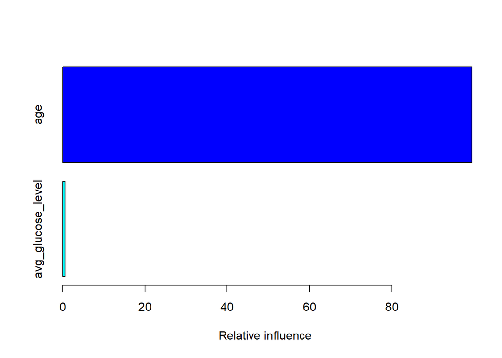

```
##                                 var    rel.inf
## age                             age 99.4346081
## avg_glucose_level avg_glucose_level  0.5653919
## hypertension           hypertension  0.0000000
## heart_disease         heart_disease  0.0000000
## smoking_status       smoking_status  0.0000000
## ever_married           ever_married  0.0000000
```

```r
model_boost <- gbm(
    stroke ~ .,
    distribution = "bernoulli",
    data = data_train_aux,
    shrinkage = 0.001,
    n.trees = 500
)

summary(model_boost, cBars = 2)
```

In this model (which is linear), all the influence lies on the feature `age`. This seems to be bad and a poor choice. Later, we will test all models using the testing set.

# K-Nearest Neighbours

This algorithm **only works with numeric variables** and is **sensitive to scale**.

```r
model_knn <- train(
    method = "knn",
    stroke ~ .,
    data = data_train,
    preProcess = c("center", "scale"),
    trControl = trainControl(
        method = "cv",
        number = 10,
    ),
    tuneGrid = data.frame(
        .k = 1:9
    ),
    metric = "Kappa"
)

model_knn
```

```
## k-Nearest Neighbors
##
## 4100 samples
##    6 predictor
##    2 classes: '0', '1'
##
## Pre-processing: centered (8), scaled (8)
## Resampling: Cross-Validated (10 fold)
## Summary of sample sizes: 3690, 3689, 3689, 3690, 3690, 3691, ...
## Resampling results across tuning parameters:
##
##   k  Accuracy   Kappa
##   1  0.9187821   0.100137701
##   2  0.9141473   0.078772995
##   3  0.9400034   0.061560018
##   4  0.9399993   0.049424825
##   5  0.9470766   0.048129341
##   6  0.9468315   0.031747201
##   7  0.9485382   0.019239558
##   8  0.9487816   0.011228308
##   9  0.9502456  -0.002722057
##
## Kappa was used to select the optimal model using the largest value.
## The final value used for the model was k = 1.
```

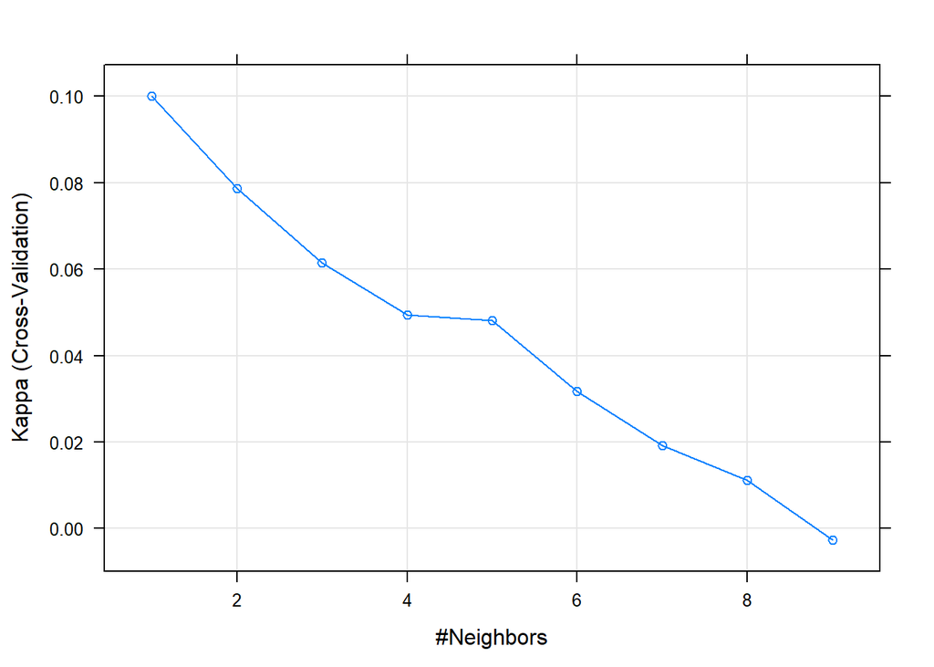

```r
plot(model_knn)
```

We see that $\kappa$ was maximised when there was a single neighbour (this makes sense since the vast majority did not have a stroke).

```r
std_scaler <- function(x) {
    ( (x - mean(x, na.rm = TRUE)) / sd(x, na.rm = TRUE) )
}

data_train_knn <- dummyVars(
    ~ ., #Expand everything
    data = data_train %>% dplyr::select(-stroke), #Do not use the response
    sep = "_"
)
data_train_knn <- predict(
    data_train_knn,
    newdata = data_train %>% dplyr::select(-stroke)
) #This actually creates the data frame
data_train_knn <- apply(data_train_knn, 2, std_scaler)


###Ditto for the test data
data_test_knn <- dummyVars(
    ~ ., #Expand everything
    data = data_test %>% dplyr::select(-stroke), #Do not use the response
    sep = "_"
)
data_test_knn <- predict(
    data_test_knn,
    newdata = data_test %>% dplyr::select(-stroke)
)
data_test_knn <- apply(data_test_knn, 2, std_scaler)

model_knn <- knn3(
    x = data_train_knn,
    y = data_train$stroke,
    prob = TRUE,
    k = 1
)
```

# Random forest

We now will try to fit a random forest. There are two parameters that we need to select. The number of trees in the forest and the number of features each tree is allowed to select.

```r
#We use the same k and folds from before
num_trees <- c(750, 1000, 1500, 2000)
num_featu <- c(5,6)

cv_ranForst <- array(NA, dim = c(k, length(num_trees), length(num_featu)), dimnames = list(paste(1:k), num_trees, num_featu))

for (i in 1:k) {
    for (m in seq_along(num_trees)) {
        for (f in seq_along(num_featu)) {
            temp_model <- randomForest(
                stroke ~ .,
                data = data_train[folds != i, ],
                ntree = num_trees[[m]],
                mtry = num_featu[[f]]
            )
            temp_pred <- predict(temp_model, newdata = data_train[folds == i, ])
            temp_pos_class <- sum(data_train$stroke[folds == i] == 1) #Count how many had stroke in this fold
            cv_ranForst[i, m, f] <- sum( (temp_pred == 1) & (data_train$stroke[folds == i] == 1) ) / temp_pos_class
        }
    }
}

cv_ranForst_means <- apply(cv_ranForst, c(2,3), mean)
```

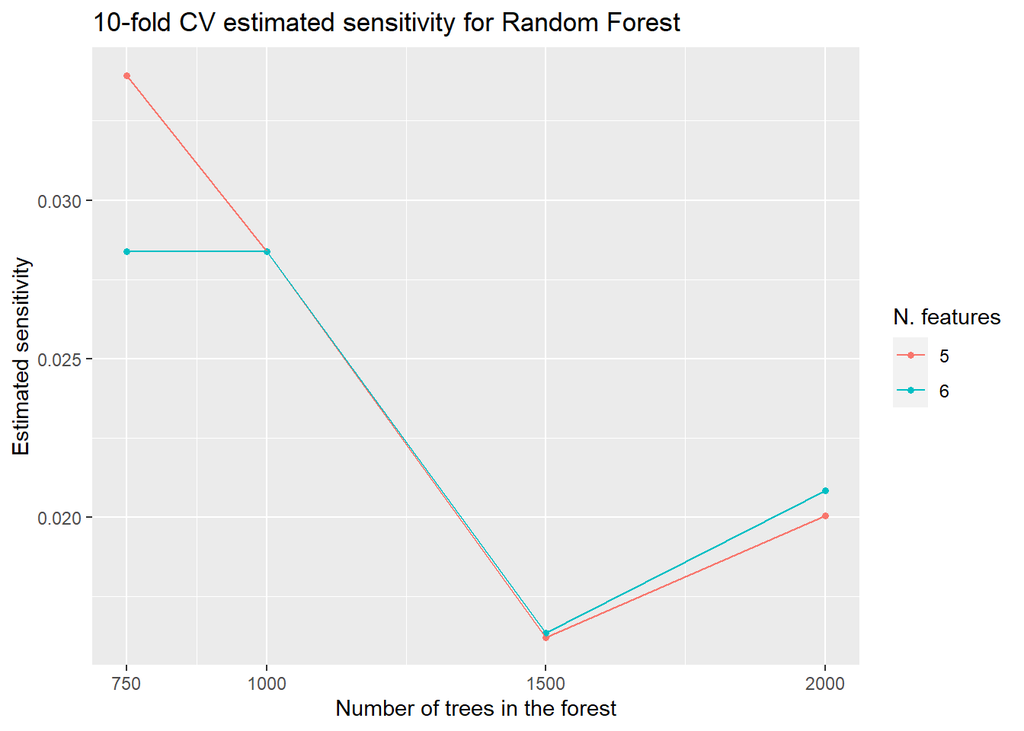

```r
cv_ranForst_means <- as_tibble(cv_ranForst_means) %>%
    mutate(
        n_trees = num_trees
    ) %>%
    pivot_longer(
        cols = as.character(num_featu),
        names_to = "num_feat",
        values_to = "est_acc"
    )

cv_ranForst_means %>% ggplot(aes(n_trees, est_acc, colour = num_feat)) +
    geom_point(size = 1.25) +
    geom_line() +
    labs(
        title = "10-fold CV estimated sensitivity for Random Forest",
        x = "Number of trees in the forest",
        y = "Estimated sensitivity",
        colour = "N. features"
    ) +
    scale_x_continuous(breaks = num_trees)
```

We then create a random forest classifier using 5 features and 750 trees

```r
model_ranForst <- randomForest(
    stroke ~ .,
    data = data_train,
    ntree = 750,
    mtry = 5,
    importance = TRUE
)
```

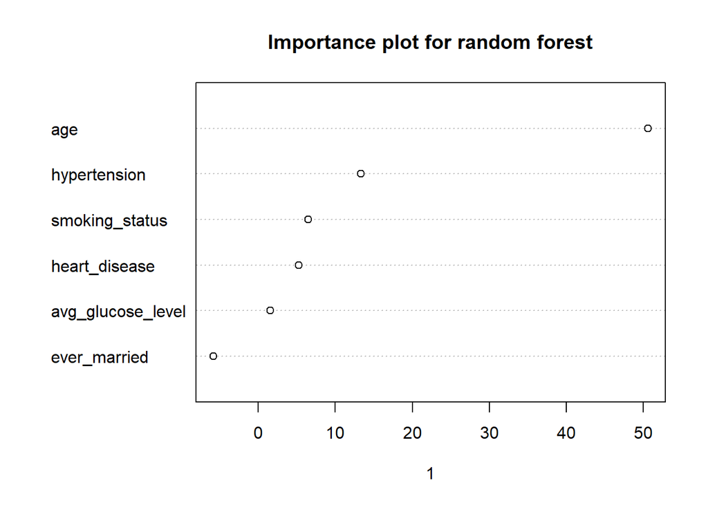

```r
varImpPlot(
    model_ranForst,
    type = 1,
    class = 1,
    main = "Importance plot for random forest"
)
```

# Testing the models.

We have trained several models, from very simple (Naïve Bayes and Logistic Regression) to more complex (Random Forest Classifier). We now compare them using the test data and creating a **ROC** curve and report its **AUC**.

```r
pred_prob_naive <- predict(
    model_naive,
    newdata = data_test,
    type = "raw"
)[, 2] #Only want the probabilites of stroke

pred_prob_lda <- predict(
    model_lda,
    newdata = data_test
)$posterior[, 2]

pred_prob_qda <- predict(
    model_qda,
    newdata = data_test
)$posterior[, 2]

pred_prob_BIC <- predict(
    model_logis_BIC_best,
    newdata = data_test,
    type = "response"
)

pred_prob_AIC <- predict(
    model_logis_AIC_best,
    newdata = data_test,
    type = "response"
)

pred_prob_logis_full <- predict(
    model_logis_full,
    newdata = data_test,
    type = "response"
)

pred_prob_boost <- predict(
    model_boost,
    newdata = data_test_aux,
    type = "response"
)

pred_prob_knn <- predict(
    model_knn,
    newdata = data_test_knn,
    type = "prob"
)[, 2]


pred_prob_ranForst <- predict(
    model_ranForst,
    newdata = data_test,
    type = "prob"
)[, 2]
```

```r
roc_curve <- function(pred, truth) {
    temp_pred <- prediction(pred, truth)

    temp_perf <- performance(temp_pred, measure = "tpr", x.measure = "fpr")
    temp_auc  <- performance(temp_pred, measure = "auc")@y.values[[1]]
    return(list(temp_perf, temp_auc))
}

roc_naive <- roc_curve(
    pred_prob_naive,
    data_test$stroke
)

roc_lda <- roc_curve(
    pred_prob_lda,
    data_test$stroke
)

roc_qda <- roc_curve(
    pred_prob_qda,
    data_test$stroke
)

roc_BIC <- roc_curve(
    pred_prob_BIC,
    data_test$stroke
)

roc_AIC <- roc_curve(
    pred_prob_AIC,
    data_test$stroke
)

roc_logis_full <- roc_curve(
    pred_prob_logis_full,
    data_test$stroke
)

roc_boost <- roc_curve(
    pred_prob_boost,
    data_test$stroke
)

roc_knn <- roc_curve(
    pred_prob_knn,
    data_test$stroke
)

roc_ranForst <- roc_curve(
    pred_prob_ranForst,
    data_test$stroke
)
```

# ROC Logistic

```r
plot_auroc <- function(object, main = "") {
    plot(object[[1]], main = main, colorize = TRUE)
    legend("center",
       legend = paste("AUC:", round(object[[2]], 3)),
       box.lty = 0
    )
}
```

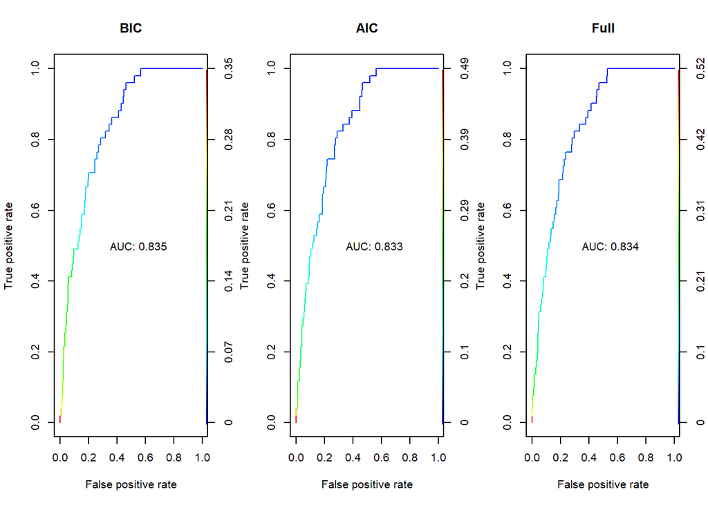

```r
par(mfrow = c(1, 3))
plot_auroc(roc_BIC, main = "BIC")
plot_auroc(roc_AIC, main = "AIC")
plot_auroc(roc_logis_full, main = "Full")
```

# ROC Naïve Bayes, Linear and Quadratic Discriminant Analyses

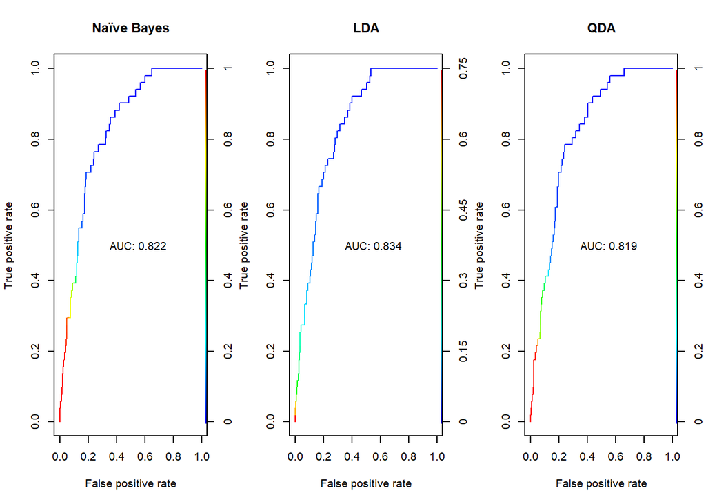

```r
par(mfrow = c(1, 3))
plot_auroc(roc_naive, main = "Naïve Bayes")
plot_auroc(roc_lda, main = "LDA")
plot_auroc(roc_qda, main = "QDA")
```

# ROC Boosting and Random Forest

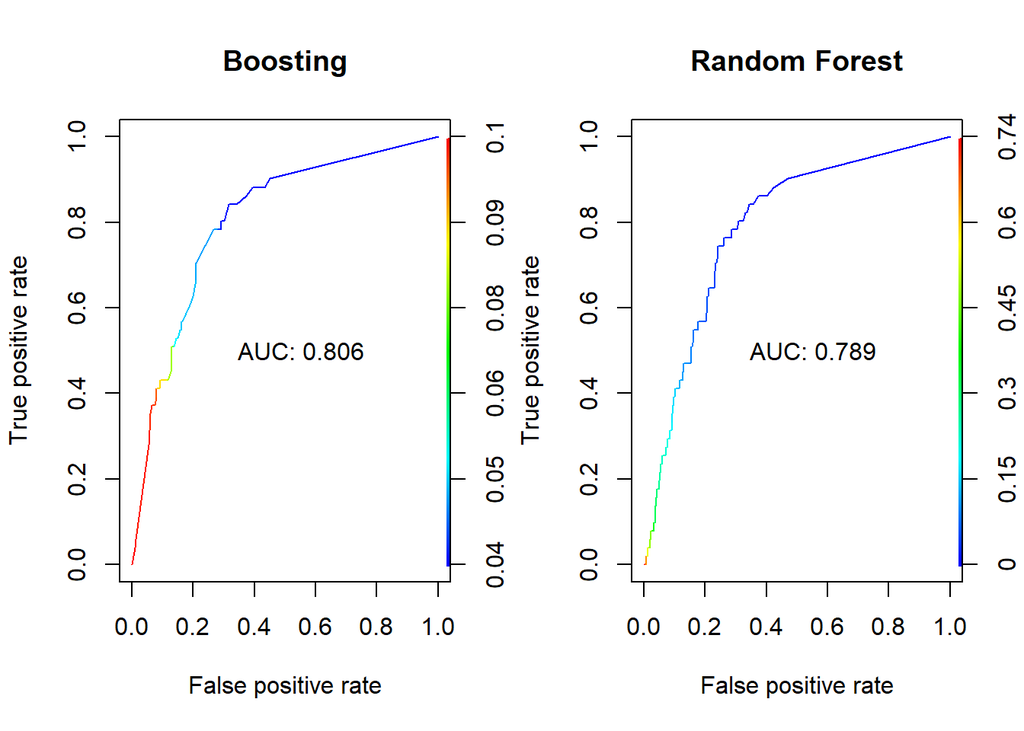

```r
par(mfrow = c(1, 2))
plot_auroc(roc_boost, main = "Boosting")
plot_auroc(roc_ranForst, main = "Random Forest")
```

# ROC K-Nearest Neighbours: 1 neighbour

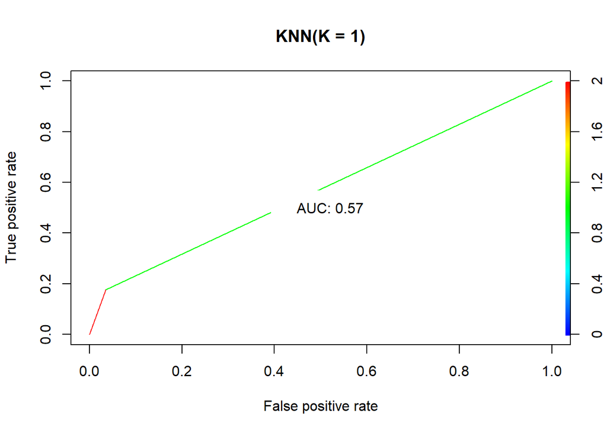

```r
plot_auroc(roc_knn, main = "KNN(K = 1)")
```

# Conclusions

Any of the basic classifiers: Logistic Regression, Naïve Bayes, Linear and Quadratic Discriminant Analyses seem to perform about the same. Any of these models can then be passed to a professional of the field who may choose, based on what they may consider a good trade-off between the FPR and TPR.

Another option would to create an **ensemble classifier.** Having set a trade-off between FPR and TPR, we can set the cut-off probabilities for the best models here and obtain their responses and finally take a majority vote for prediction.

Another possibility is to include interaction terms between age and the variables found. For example, Logistic Regression as selected by BIC has the features age and average level of glucose in the blood. These two features are also related and an interaction term may then be sound.

# After thougths

Let us do the Logistic Regression with an interaction between age and glucose level.

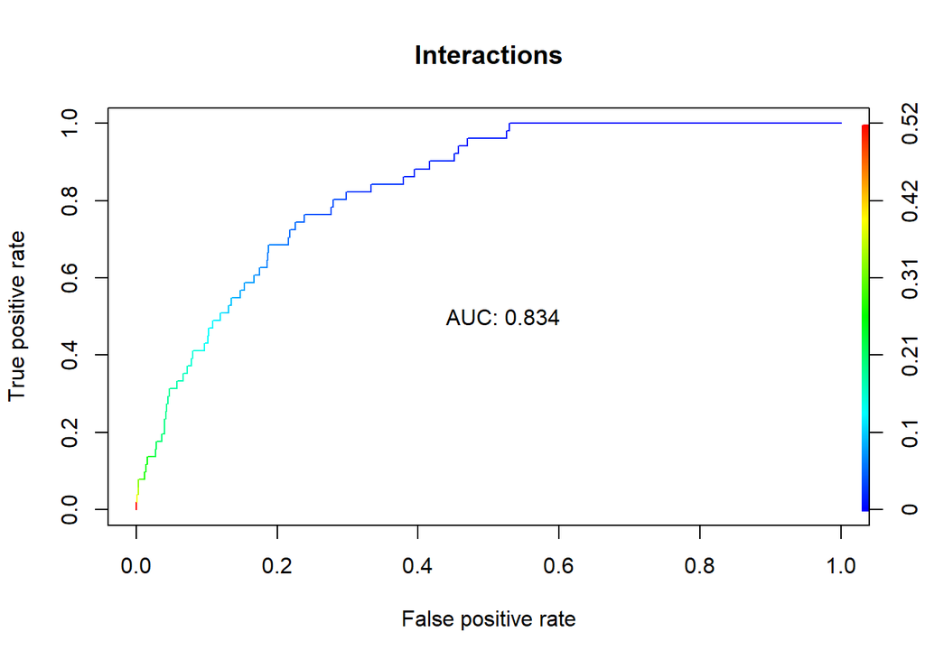

```r
model_logis_inter <- glm(
    stroke ~ age + avg_glucose_level + age : avg_glucose_level,
    data = data_train,
    family = binomial
)
pred_prob_logis_inter <- predict(
    model_logis_inter,
    newdata = data_test,
    type = "response"
)
roc_logis_inter <- roc_curve(
    pred_prob_logis_full,
    data_test$stroke
)
plot_auroc(roc_logis_inter, main = "Interactions")
```